# Data 622 - Homework #4 (Group 2)

### Hierarchical Clustering

Hierarchical clustering, also known as hierarchical cluster analysis, is an algorithm that groups similar objects into groups called clusters. The endpoint is a set of clusters, where each cluster is distinct from each other cluster, and the objects within each cluster are broadly similar to each other.

There are 5 main methods to measure the distance between clusters, referred as linkage methods:

- **Single linkage**: computes the minimum distance between clusters before merging them.
- **Complete linkage**: computes the maximum distance between clusters before merging them.
- **Average linkage**: computes the average distance between clusters before merging them.
- **Centroid linkage**: calculates centroids for both clusters, then computes the distance between the two before merging them.
- **Ward’s (minimum variance) criterion**: minimizes the total within-cluster variance and find the pair of clusters that leads to minimum increase in total within-cluster variance after merging.

We can apply the hierarchical clustering with the complete linkage criterion thanks to the hclust() function with the argument method = “complete” and method = “ward.D2”:

```r
d <- dist(df_dummy, method = "euclidean")
hclust1 <- hclust(d, method = "complete")
```

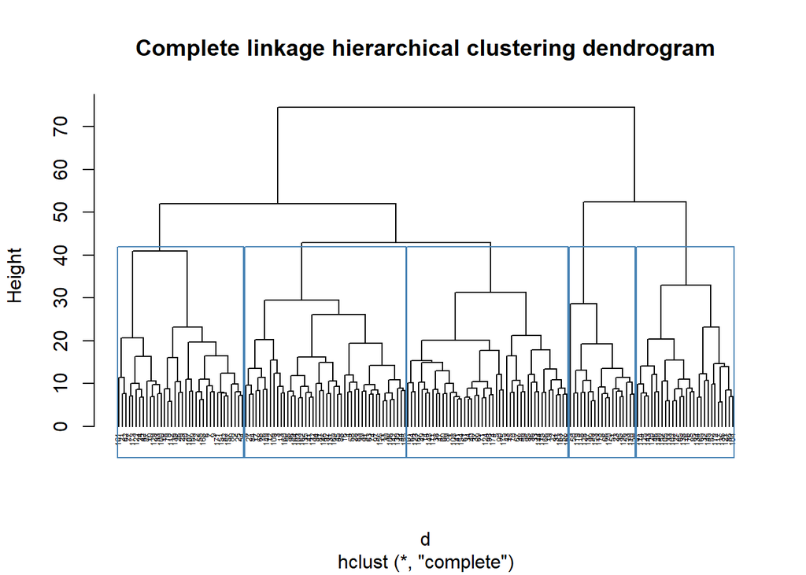

```r
plot(hclust1, hang = -1, cex = 0.4, main = "Complete linkage hierarchical clustering dendrogram")
rect.hclust(hclust1,
  k = 5, # k is used to specify the number of clusters
  border = "steelblue"
)
```

Above, we can see the visual representation of our complete linkage hierarchical clustering dendrogram, including the 5 deliniated clusters in blue. Later, we can compare this to the Ward’s method hierarchical clustering dendrogram that is presented below:

```r
hclust2 <- hclust(d, method = "ward.D2")
```

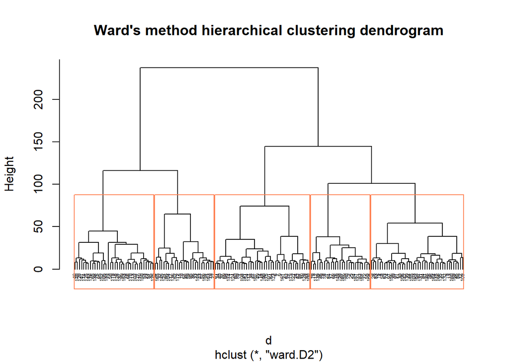

```r
plot(hclust2, hang = -1, cex = 0.4, main = "Ward's method hierarchical clustering dendrogram")
rect.hclust(hclust2,
  k = 5, # k is used to specify the number of clusters
  border = "coral"
)
```

We compare hierarchical clustering with complete linkage versus Ward’s method. The function tanglegram plots two dendrograms, side by side, with their labels connected by lines.

```r
dend1 <- as.dendrogram (hclust1)
dend2 <- as.dendrogram (hclust2)
```

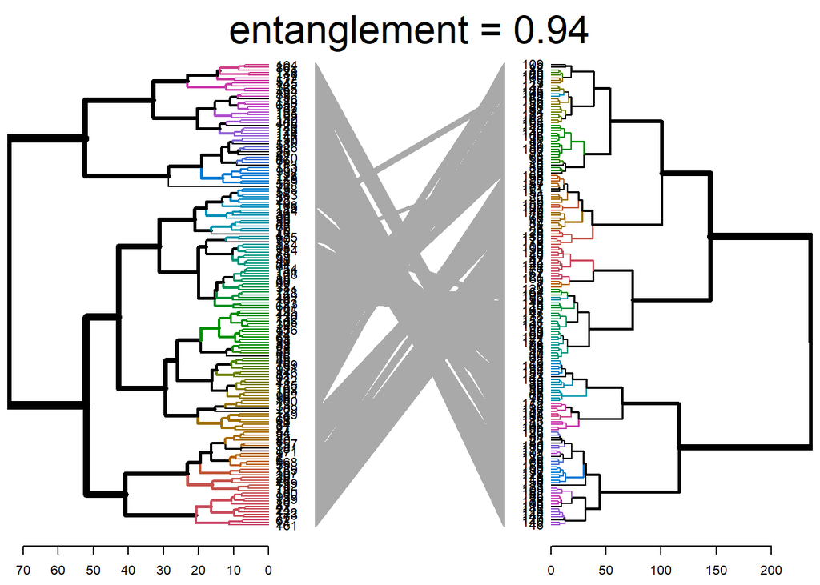

```r
dend_list <- dendlist(dend1, dend2)

tanglegram(dend1, dend2,
  highlight_distinct_edges = FALSE, # Turn-off dashed lines
  common_subtrees_color_lines = FALSE, # Turn-off line colors
  common_subtrees_color_branches = TRUE, # Color common branches
  main = paste("entanglement =", round(entanglement(dend_list), 2))
  )
```

As we can see above, the entanglement value of 0.94 is very close to 1, meaning that there isn’t a lot of alignment between the two dendrograms. Additionally, when we use the `cor_cophenetic()` and `cor_bakers_gamma()` functions, which measure the Cophenetic and Baker correlation coefficient’s respectively, we can see that both of these values fall between 0.6 and 0.7. This indicates that there is some correlation between the two dendrograms, but they aren’t *very* correlated with one another.

```r
paste0('Cophenetic correlation coefficient: ', cor_cophenetic(dend_list))
```

```
## [1] "Cophenetic correlation coefficient: 0.676520209392845"
```

```r
paste0('Baker correlation coefficient: ', cor_bakers_gamma(dend_list))
```

```
## [1] "Baker correlation coefficient: 0.618243044947494"
```

Given our hierarchical clustering techniques, we decided to try and visualize characteristics across each of our five clusters for our complete linkage HC model. To do this, we decided to create a heatmap which shows the percent of each factor level (i.e. every value of 1) in the absolute count of cluster members, to determine which factors seemed to be found the most among members of each cluster.

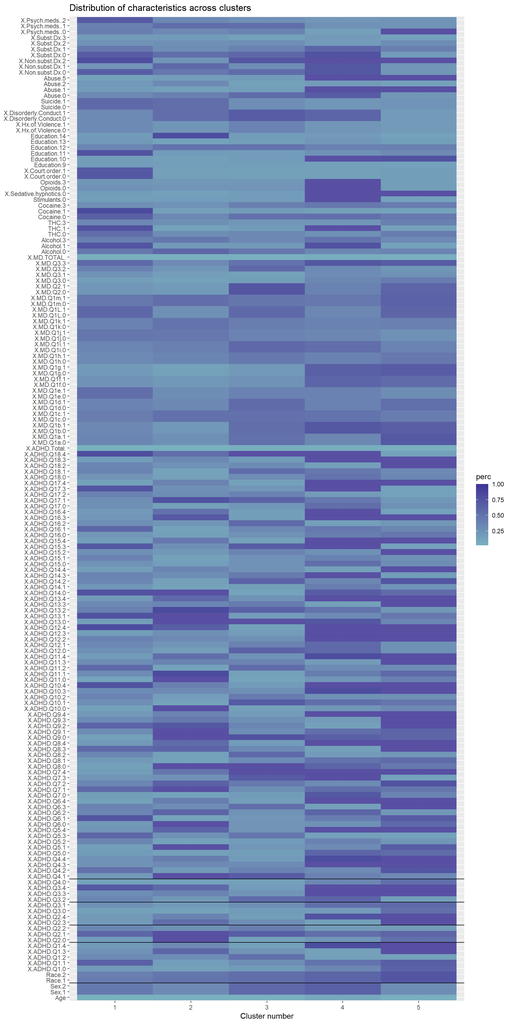

```r
require(reshape2)
# Time for the heatmap
# the 1st step here is to have 1 variable per row
# factors have to be converted to characters in order not to be dropped
clust.num <- cutree(hclust1, k = 5)
df.cl <- cbind(df_dummy, clust.num)
df.cl <- df.cl %>% mutate(rownum = row_number())
df.long <- melt(data.frame(lapply(df.cl, as.character), stringsAsFactors=FALSE),
                  id = c("rownum", "clust.num"), factorsAsStrings=T)
df.long.q <- df.long %>%
  group_by(clust.num, variable, value) %>%
  mutate(count = n_distinct(rownum)) %>%
  distinct(clust.num, variable, value, count)

#heatmap.c will be suitable in case you want to go for absolute counts - but it doesn't tell much to my taste
heatmap.c <- ggplot(df.long.q, aes(x = clust.num, y = variable, ordered = T)) +

  geom_tile(aes(fill = count))+
  scale_fill_gradient2(low = "darkslategray1", mid = "yellow", high = "turquoise4")


# heatmap.c

# calculating the percent of each factor level in the absolute count of cluster members
df.long.p <- df.long.q %>%
  group_by(clust.num, variable) %>%
  mutate(perc = count / sum(count)) %>%
  arrange(clust.num)

heatmap.p <- ggplot(df.long.p, aes(x = clust.num, y = variable, ordered = T)) +

geom_tile(aes(fill = perc), alpha = 0.85)+
  labs(title = "Distribution of characteristics across clusters", x = "Cluster number", y = NULL) +
  geom_hline(yintercept = 3.5) +
  geom_hline(yintercept = 10.5) +
  geom_hline(yintercept = 13.5) +
  geom_hline(yintercept = 17.5) +
  geom_hline(yintercept = 21.5) +
  scale_fill_gradient2(low = "#E8D5B5", mid = "#7AB4C0", high = "#3E3496")
heatmap.p
```

From our above visualization, we can see a few distinct trends:

- **Cluster 1**: we can see here that most members of in this cluster use cocaine, THC, and alcohol, have an education level at 11th grade (indicating they do not have a high school diploma), and take more than one psychotropic medication.
- **Cluster 2**: we can see here that most of the members of this cluster have an education level at the college level (13 or above), do not use alcohol, and agreed consistently with a response of “rarely” for many of the ADHD questions. With further metadata on the survey questions, we’d be able to identify even more trends based on these questions.
- **Cluster 3**: we can see here that most members of this cluster had more than one non-substance-related disorder and answered with “sometimes” or “often” more frequently on ADHD questions.
- **Cluster 4**: we can see here that most members of this cluster had experienced physical abuse, or a combination of physical and emotional abuse, answered “very often” on a lot of the ADHD questions, were users of THC and alcohol, and had a low education level (around 10th grade).
- **Cluster 5**: we can see here that most members of this cluster also answered “very often” on a lot of the ADHD questions and were less likely to use sedative hypnotics and psychiatric medications than other clusters.

## **Part 2: Principal Component Analysis (PCA)**

Let’s explore using Principal Component Analysis on this dataset. You will note that there are different types of questions in the dataset: **columns E-W**: ADHD self-report; **column X–AM**: mood disorders questionnaire, **column AN-AS**: Individual Substance Misuse; etc. Please reason through your work as you decide on which sets of variables you want to use to conduct Principal Component Analysis. *(60)*

Principal Component Analysis (PCA) is an unsupervised, non-parametric statistical technique primarily used for dimensionality reduction in machine learning. It is a useful technique for exploratory data analysis, allowing us to better visualize the variation present in a dataset with many variables. For our particular use case here, it appears that many of the questionnaire variables fall on likert scales, which when prepared for analysis are extended to dummy variables. This creates many additional features and can make analysis more difficult due to an increased number of dimensions. Therefore, utilizing PCA to reduce the number of dimensions on our entired dataset and measure the amount of variance explained is beneficial. In order to do this, we’ll use the `prcomp()` function:

```r
df_dummy.pca <- prcomp(df_dummy, center = TRUE,scale. = TRUE)

summary(df_dummy.pca)
```

```
## Importance of components:
##                           PC1     PC2     PC3     PC4     PC5    PC6     PC7
## Standard deviation     4.5376 3.18663 2.73537 2.32943 2.16129 2.0739 1.95356
## Proportion of Variance 0.1211 0.05973 0.04401 0.03192 0.02748 0.0253 0.02245
## Cumulative Proportion  0.1211 0.18085 0.22486 0.25678 0.28426 0.3096 0.33201
##                            PC8     PC9    PC10    PC11    PC12    PC13    PC14
## Standard deviation     1.92898 1.88273 1.80904 1.77187 1.74963 1.73401 1.69848
## Proportion of Variance 0.02189 0.02085 0.01925 0.01847 0.01801 0.01769 0.01697
## Cumulative Proportion  0.35390 0.37475 0.39400 0.41247 0.43047 0.44816 0.46513
##                           PC15    PC16    PC17    PC18    PC19    PC20    PC21
## Standard deviation     1.68709 1.63613 1.60444 1.57041 1.55859 1.53553 1.51945
## Proportion of Variance 0.01674 0.01575 0.01514 0.01451 0.01429 0.01387 0.01358
## Cumulative Proportion  0.48187 0.49762 0.51276 0.52727 0.54156 0.55543 0.56901
##                           PC22    PC23    PC24    PC25    PC26    PC27    PC28
## Standard deviation     1.48822 1.47627 1.44932 1.43317 1.42505 1.40096 1.35289
## Proportion of Variance 0.01303 0.01282 0.01236 0.01208 0.01195 0.01155 0.01077
## Cumulative Proportion  0.58204 0.59486 0.60721 0.61930 0.63124 0.64279 0.65355
##                           PC29    PC30    PC31    PC32    PC33   PC34    PC35
## Standard deviation     1.33229 1.32665 1.31559 1.30793 1.28983 1.2712 1.26500
## Proportion of Variance 0.01044 0.01035 0.01018 0.01006 0.00979 0.0095 0.00941
## Cumulative Proportion  0.66399 0.67435 0.68453 0.69459 0.70438 0.7139 0.72330
##                           PC36    PC37    PC38    PC39    PC40    PC41    PC42
## Standard deviation     1.23800 1.23160 1.21727 1.18520 1.17638 1.14582 1.13364
## Proportion of Variance 0.00902 0.00892 0.00872 0.00826 0.00814 0.00772 0.00756
## Cumulative Proportion  0.73231 0.74123 0.74995 0.75821 0.76635 0.77408 0.78164
##                           PC43    PC44    PC45    PC46    PC47   PC48    PC49
## Standard deviation     1.12521 1.09399 1.07900 1.06334 1.05498 1.0350 1.02503
## Proportion of Variance 0.00745 0.00704 0.00685 0.00665 0.00655 0.0063 0.00618
## Cumulative Proportion  0.78908 0.79612 0.80297 0.80962 0.81617 0.8225 0.82865
##                           PC50    PC51    PC52   PC53    PC54    PC55    PC56
## Standard deviation     1.01966 0.99640 0.98515 0.9841 0.94749 0.93823 0.92943
## Proportion of Variance 0.00612 0.00584 0.00571 0.0057 0.00528 0.00518 0.00508
## Cumulative Proportion  0.83477 0.84061 0.84632 0.8520 0.85729 0.86247 0.86755
##                           PC57    PC58    PC59    PC60    PC61    PC62    PC63
## Standard deviation     0.91723 0.91116 0.89074 0.88521 0.87092 0.86147 0.85339
## Proportion of Variance 0.00495 0.00488 0.00467 0.00461 0.00446 0.00437 0.00428
## Cumulative Proportion  0.87250 0.87739 0.88205 0.88666 0.89112 0.89549 0.89977
##                           PC64    PC65   PC66    PC67    PC68    PC69    PC70
## Standard deviation     0.84359 0.82856 0.8144 0.80802 0.77716 0.77408 0.76361
## Proportion of Variance 0.00419 0.00404 0.0039 0.00384 0.00355 0.00352 0.00343
```

[output cut: 54 more lines]

```
## Standard deviation     2.981e-16 2.981e-16 2.981e-16 2.981e-16 2.981e-16
## Proportion of Variance 0.000e+00 0.000e+00 0.000e+00 0.000e+00 0.000e+00
## Cumulative Proportion  1.000e+00 1.000e+00 1.000e+00 1.000e+00 1.000e+00
##                            PC158     PC159     PC160     PC161     PC162
## Standard deviation     2.981e-16 2.981e-16 2.981e-16 2.981e-16 2.981e-16
## Proportion of Variance 0.000e+00 0.000e+00 0.000e+00 0.000e+00 0.000e+00
## Cumulative Proportion  1.000e+00 1.000e+00 1.000e+00 1.000e+00 1.000e+00
##                            PC163     PC164     PC165     PC166     PC167
## Standard deviation     2.981e-16 2.981e-16 2.981e-16 2.681e-16 2.186e-16
## Proportion of Variance 0.000e+00 0.000e+00 0.000e+00 0.000e+00 0.000e+00
## Cumulative Proportion  1.000e+00 1.000e+00 1.000e+00 1.000e+00 1.000e+00
##                            PC168     PC169     PC170
## Standard deviation     1.306e-16 1.238e-16 4.126e-17
## Proportion of Variance 0.000e+00 0.000e+00 0.000e+00
## Cumulative Proportion  1.000e+00 1.000e+00 1.000e+00
```

The scale = 0 argument to biplot ensures that the arrows are scaled to represent the loadings; other values for scale give slightly different biplots with different interpretations.

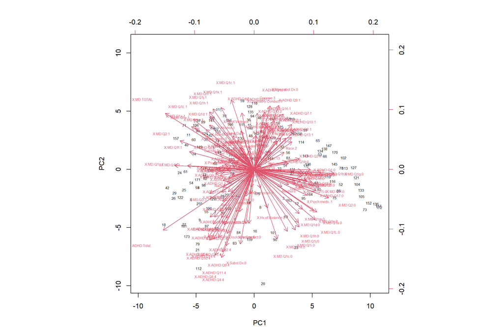

```r
biplot(df_dummy.pca, scale = 0, cex=0.5)
```

From the biplot above, it’s difficult to tell much given the very large number of features. However, from our PCA analysis, we can also take a look at the eigenvalues that were generated by using a scree plot. The plot below shows the percentage of variance explained by each principal component.

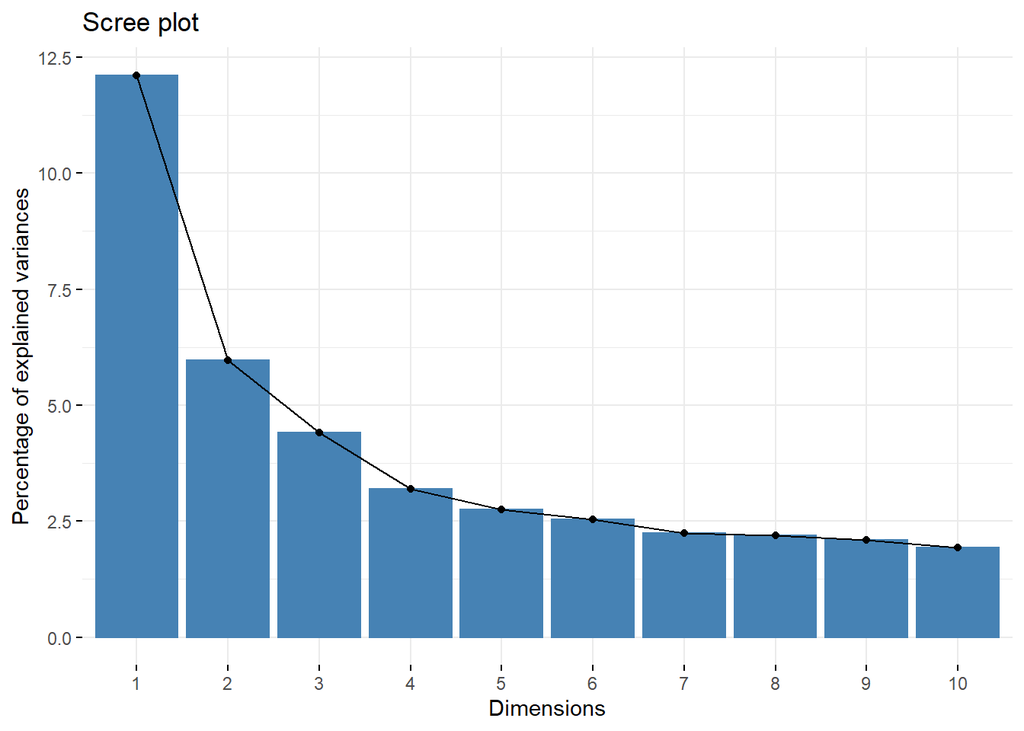

```r
fviz_eig(df_dummy.pca)
```

```r
#compute standard deviation of each principal component
std_dev <- df_dummy.pca$sdev

#compute variance
pr_var <- std_dev^2


prop_varex <- pr_var/sum(pr_var)

round(prop_varex[1:10], 2)
```

```
##  [1] 0.12 0.06 0.04 0.03 0.03 0.03 0.02 0.02 0.02 0.02
```

The first principal component in our example therefore explains 12% of the variability, and the second principal component explains 6%. Together, the first ten principal components explain 39% of the variability. And we proceed to plot the PVE and cumulative PVE to provide us our scree plots as we did earlier.

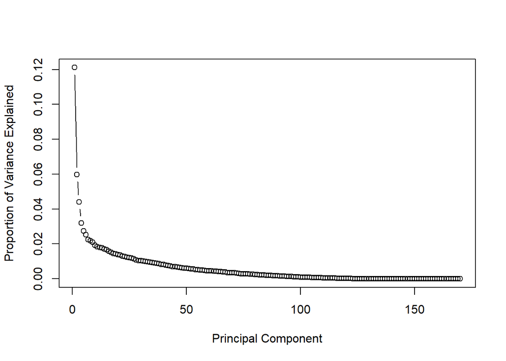

```r
#scree plot
plot(prop_varex, xlab = "Principal Component",
             ylab = "Proportion of Variance Explained",
             type = "b")
```

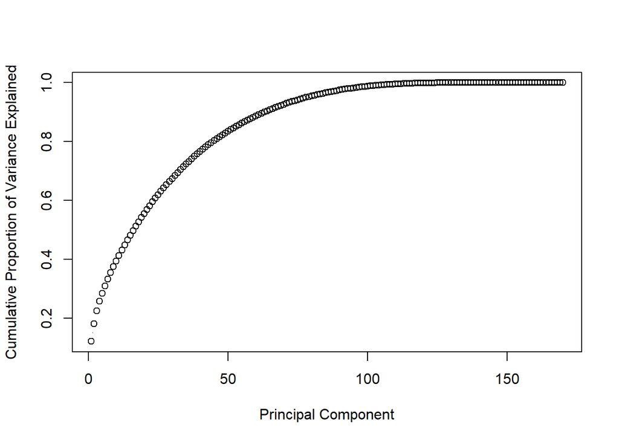

```r
#cumulative scree plot
plot(cumsum(prop_varex), xlab = "Principal Component",
              ylab = "Cumulative Proportion of Variance Explained",
              type = "b")
```

As we can see above in our plots of the PVE and the cumultative PVE, the first few principal components account for a much larger proportion of the variance explained than the remaining 150+ principal components for this dataset. Additionally, the proportion of variance explained by the first principal component at 12% is double the second principal component’s proportion of variance explained.

Although running PCA on the entire dataset is helpful in some ways, certain findings from a biplot are affected by the number of variables in the overall dataset. Additionally, we are seeing from our PCA analysis that the first few principal components explain a much larger proportion of the variability than later principal compnents. Because of this, we thought it would be interesting to dive a bit deeper into which variables seem to hold the most importance in determining the first few dimensions. To do this, we’ll use the `FactoMineR` and `factoextra` packages to determine the eigenvalues of each dimension, with particular interest in dimensions 1 and 2, since those are what we’ve plotted above and hold the highest proportion of variance explained.

```r
library("FactoMineR")
library("factoextra")

eig.val <- get_eigenvalue(df_dummy.pca)
eig.val
```

```
##           eigenvalue variance.percent cumulative.variance.percent
## Dim.1   2.058998e+01     1.211175e+01                    12.11175
## Dim.2   1.015460e+01     5.973293e+00                    18.08505
## Dim.3   7.482244e+00     4.401320e+00                    22.48637
## Dim.4   5.426226e+00     3.191898e+00                    25.67826
## Dim.5   4.671181e+00     2.747754e+00                    28.42602
## Dim.6   4.301045e+00     2.530027e+00                    30.95604
## Dim.7   3.816415e+00     2.244950e+00                    33.20099
## Dim.8   3.720982e+00     2.188813e+00                    35.38981
## Dim.9   3.544675e+00     2.085103e+00                    37.47491
## Dim.10  3.272608e+00     1.925064e+00                    39.39997
## Dim.11  3.139506e+00     1.846768e+00                    41.24674
## Dim.12  3.061203e+00     1.800708e+00                    43.04745
## Dim.13  3.006795e+00     1.768703e+00                    44.81615
## Dim.14  2.884835e+00     1.696962e+00                    46.51311
## Dim.15  2.846258e+00     1.674270e+00                    48.18738
## Dim.16  2.676906e+00     1.574651e+00                    49.76204
## Dim.17  2.574236e+00     1.514256e+00                    51.27629
## Dim.18  2.466179e+00     1.450694e+00                    52.72699
## Dim.19  2.429208e+00     1.428946e+00                    54.15593
## Dim.20  2.357853e+00     1.386972e+00                    55.54290
## Dim.21  2.308716e+00     1.358068e+00                    56.90097
## Dim.22  2.214809e+00     1.302829e+00                    58.20380
## Dim.23  2.179384e+00     1.281990e+00                    59.48579
## Dim.24  2.100534e+00     1.235608e+00                    60.72140
## Dim.25  2.053975e+00     1.208220e+00                    61.92962
## Dim.26  2.030759e+00     1.194564e+00                    63.12418
## Dim.27  1.962699e+00     1.154529e+00                    64.27871
## Dim.28  1.830307e+00     1.076651e+00                    65.35536
## Dim.29  1.774996e+00     1.044115e+00                    66.39948
## Dim.30  1.759998e+00     1.035293e+00                    67.43477
## Dim.31  1.730765e+00     1.018097e+00                    68.45287
## Dim.32  1.710675e+00     1.006279e+00                    69.45915
## Dim.33  1.663649e+00     9.786172e-01                    70.43777
## Dim.34  1.615838e+00     9.504927e-01                    71.38826
## Dim.35  1.600213e+00     9.413019e-01                    72.32956
## Dim.36  1.532634e+00     9.015492e-01                    73.23111
## Dim.37  1.516842e+00     8.922598e-01                    74.12337
## Dim.38  1.481739e+00     8.716111e-01                    74.99498
## Dim.39  1.404703e+00     8.262958e-01                    75.82128
```

[output cut: 116 more lines]

```
## Dim.156 8.884720e-32     5.226306e-32                   100.00000
## Dim.157 8.884720e-32     5.226306e-32                   100.00000
## Dim.158 8.884720e-32     5.226306e-32                   100.00000
## Dim.159 8.884720e-32     5.226306e-32                   100.00000
## Dim.160 8.884720e-32     5.226306e-32                   100.00000
## Dim.161 8.884720e-32     5.226306e-32                   100.00000
## Dim.162 8.884720e-32     5.226306e-32                   100.00000
## Dim.163 8.884720e-32     5.226306e-32                   100.00000
## Dim.164 8.884720e-32     5.226306e-32                   100.00000
## Dim.165 8.884720e-32     5.226306e-32                   100.00000
## Dim.166 7.189656e-32     4.229210e-32                   100.00000
## Dim.167 4.779747e-32     2.811616e-32                   100.00000
## Dim.168 1.706728e-32     1.003958e-32                   100.00000
## Dim.169 1.532521e-32     9.014831e-33                   100.00000
## Dim.170 1.702189e-33     1.001288e-33                   100.00000
```

```r
res.pca <- PCA(df_dummy, scale.unit = TRUE, ncp = 5, graph = FALSE)
var <- get_pca_var(res.pca)
```

Since our biplot above was very crowded and difficult to interpret, we decided to look a bit deeper at the quality of representation of the variables, which is determined by taking the square cosine (cos2) and accounts for a variable’s position relative to the circumference of the correlation circle (not pictured in our biplot above but can be visually seen by the length of each vector from the center/origin). After subjecting these cos2 values to a corrplot across tthe first five PCs, we can examine below:

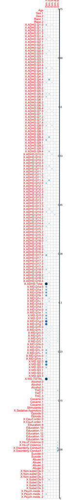

```r
library("corrplot")
corrplot(var$cos2, is.corr=FALSE)
```

Typically, a high cos2 value indicates a good representation of the variable on the principal component, and in our case the variable is positioned close to the circumference of the correlation circle (and farther away from the origin) – which we can visibly see with variables such as X.ADHD.Total and X.MD.Total on the biplot. The opposite is true for variables with a low cos2 value, which tend to fall closer to the origin.

We can also take a look at factors such as the contribution of variables on our principal components. Variables that are correlated with PC1 and PC2 are the most important in explaining the variability in the dataset. Therefore, when we conduct another correlation plot, but this time of variable contribution, we see the following:

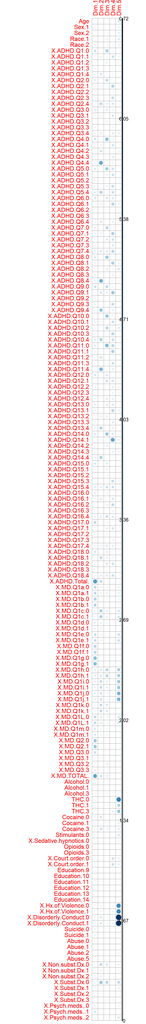

```r
corrplot(var$contrib, is.corr=FALSE)
```

We can also see this in a barplot below, and shows the variables that have the highest contribution percentage for our first two PCs:

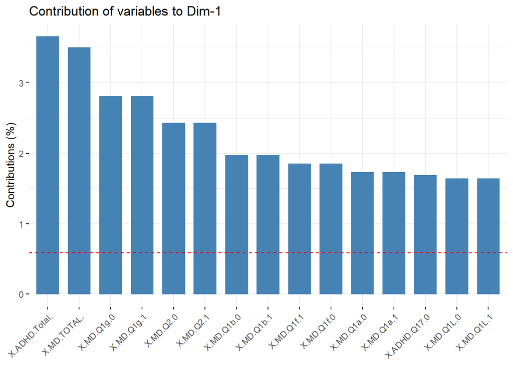

```r
fviz_contrib(df_dummy.pca, choice = "var", axes = 1, top = 15)
```

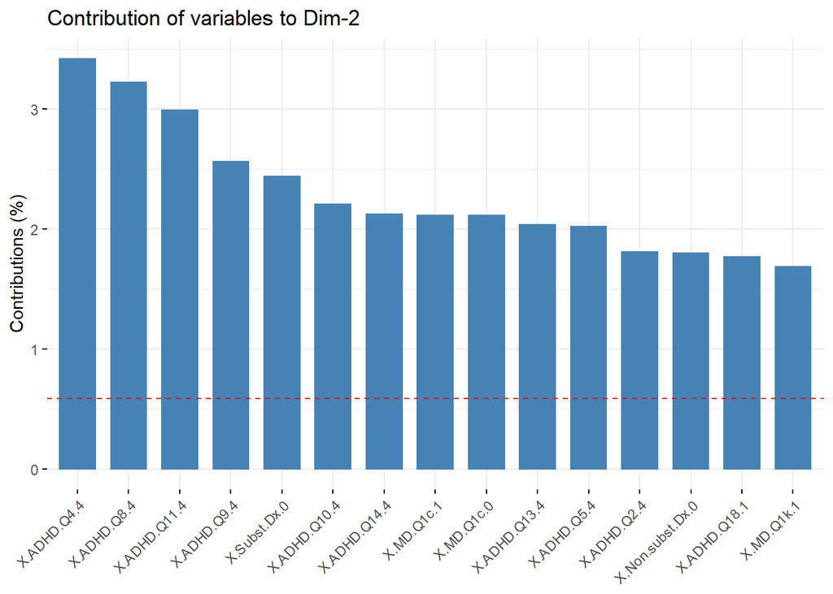

```r
fviz_contrib(df_dummy.pca, choice = "var", axes = 2, top = 15)
```

Similar to our biplot visualization and our cos2 values, we can confirm that variables such as `X.ADHD.Total` and `X.MD.Total`, as well as many other ADHD and MD questions contribute most to the variability explained in our dataset. This is important for us to take not of for future analysis, where we will be looking more closely at features that seem to provide more insight into clustering and classification.

Graph of variables. Positive correlated variables point to the same side of the plot. Negative correlated variables point to opposite sides of the graph.

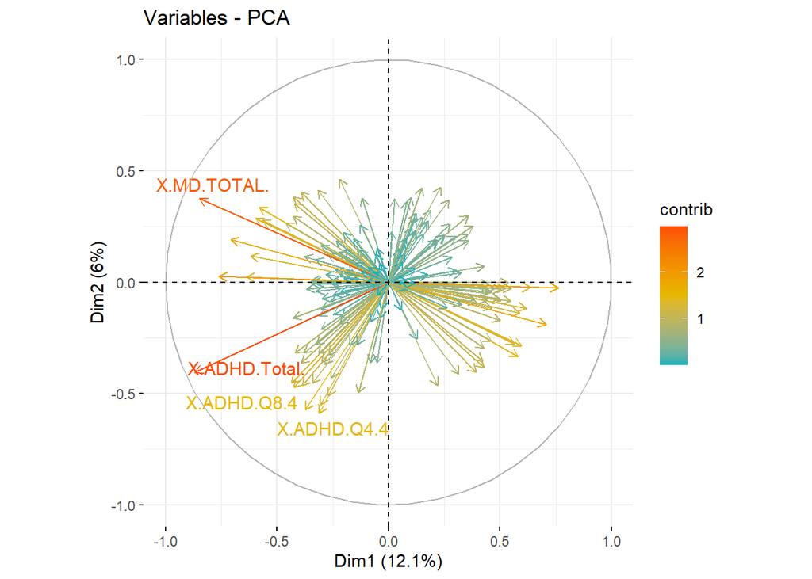

```r
fviz_pca_var(df_dummy.pca,
             col.var = "contrib", # Color by contributions to the PC
             gradient.cols = c("#00AFBB", "#E7B800", "#FC4E07"),
             repel = TRUE     # Avoid text overlapping
             )
```